# Continuous character models

Brian C. O’Meara

2/20/2017

First get packages we need

```r
library(ape) #utility fns
library(geiger) #utilty fns
library(OUwie)
library("phangorn")
library("corHMM")
library("phytools")
```

Now get the tree and data. For these exercises, knowing uncertainty in your measurements can also be important. (remember for homework to change `eval=FALSE` to `eval=TRUE`).

```r
setwd("D:/EEB 603/Code/Run 1")
source('D:/EEB 603/Code/Run 1/ContinuousFunctions.R')
source("Macaque Project Data Prep.R")
```

```
## [1] "file named D:/EEB 603/LANDMARKASCII_FILES_2/fascicularis/713.landmarkAscii contains a second matrix of 000"
```

```r
# Read in tree

tree.nex = read.nexus("D:/EEB 603/Trees/consensusTree_10kTrees_Primates_Version3.nex")
phy <- multi2di(tree.nex, random=FALSE)
treefile1 = phy

##  Pull in morphometric/behavior data to be compiled

discrete.data.raw <- read.csv("D://EEB 603/KUPRI Data/KUPRI_MAST_WITH_DISC.csv", stringsAsFactors = FALSE)
discrete.data.prep <- as.matrix(discrete.data.raw[,6])
discrete.data.prep <-`rownames<-`(discrete.data.prep, c("Pan_troglodytes_troglodytes", "Gorilla_gorilla_gorilla", "Hylobates_lar", "Macaca_sylvanus","Macaca_thibetana", "Macaca_mulatta", "Macaca_fascicularis", "Macaca_fuscata", "Macaca_cyclopis", "Macaca_nemestrina", "Macaca_silenus", "Macaca_pagensis", "Macaca_nigra", "Macaca_maura", "Macaca_sinica", "Macaca_radiata", "Macaca_assamensis", "Macaca_arctoides","Papio_hamadryas", "Theropithecus_gelada", "Mandrillus_sphinx", "Cercocebus_torquatus", "Cercocebus_galeritus","Erythrocebus_patas","Cercopithecus_neglectus","Cercopithecus_campbelli","Cercopithecus_petaurista"))
discrete.factors <- factor(discrete.data.prep)
num.vec.disc <- as.matrix(as.numeric(discrete.factors))
num.vec.disc <-`rownames<-`(num.vec.disc, c("Pan_troglodytes_troglodytes", "Gorilla_gorilla_gorilla", "Hylobates_lar", "Macaca_sylvanus","Macaca_thibetana", "Macaca_mulatta", "Macaca_fascicularis", "Macaca_fuscata", "Macaca_cyclopis", "Macaca_nemestrina", "Macaca_silenus", "Macaca_pagensis", "Macaca_nigra", "Macaca_maura", "Macaca_sinica", "Macaca_radiata", "Macaca_assamensis", "Macaca_arctoides","Papio_hamadryas", "Theropithecus_gelada", "Mandrillus_sphinx", "Cercocebus_torquatus", "Cercocebus_galeritus","Erythrocebus_patas","Cercopithecus_neglectus","Cercopithecus_campbelli","Cercopithecus_petaurista"))


## Force trees to be ultrametric

  ##  A function to do this

  force.ultrametric<-function(tree,method=c("nnls","extend")){
    method<-method[1]
    if(method=="nnls") tree<-nnls.tree(cophenetic(tree),tree,
                                       rooted=TRUE,trace=0)
    else if(method=="extend"){
      h<-diag(vcv(tree))
      d<-max(h)-h
      ii<-sapply(1:Ntip(tree),function(x,y) which(y==x),
                 y=tree$edge[,2])
      tree$edge.length[ii]<-tree$edge.length[ii]+d
    } else
      cat("method not recognized: returning input tree\n\n")
    tree
  }


 # discrete

  pruned.phy <-name.check(treefile1, num.vec.disc)
  phy.discrete <- drop.tip(treefile1, pruned.phy$tree_not_data)
  branch.time.discrete <- branching.times(phy.discrete)
  ult.phy.disc <- force.ultrametric(phy.discrete)

  is.ultrametric(ult.phy.disc)
```

```
## [1] TRUE
```

```r
  # continous

  continuous.data <- as.matrix(log(phenotype.z.complete[,1]))
  pruned.phy.cont <- name.check(treefile1, continuous.data)
  phy.cont <- drop.tip(treefile1, pruned.phy.cont$tree_not_data)
  branch.time.cont <- branching.times(phy.cont)
  ult.phy.cont <- force.ultrametric(phy.cont)

  is.ultrametric(ult.phy.cont)
```

```
## [1] TRUE
```

A function to clean data, make sure taxon names match between tree and data, etc.

```r
CleanData <- function(tree.phy, data.phy, col.no) {

  phy <- ape::reorder.phylo(tree.phy)
  data1 <- geiger::treedata(tree.phy, data.phy, sort=TRUE)$data

  data1 <- as.matrix(data.phy[match(tree.phy$tip.label, rownames(data.phy)),])

  # data1 <- `rownames<-`(data.phy)

  # data_out <- as.data.frame.vector(data1, row.names = row.names(data.phy))

    ##  Since we're doing univar for now, I'm asking for the vector of pheno vals I need

   return(data1)

}
```

# A function to plot data. Look at `phytools::contMap()`. This is all part of checking: do your data all seem sensible? **LOOK AT IT**.

```r
  pruned.phy.cont <- name.check(treefile1, continuous.data)
  phy.cont <- drop.tip(treefile1, pruned.phy.cont$tree_not_data)
  branch.time.cont <- branching.times(phy.cont)
  ult.phy.cont <- force.ultrametric(phy.cont)

Plot.phy <- function(tree.phy, main.char){

   plot.phy <- plot(tree.phy, main = main.char, show.tip.label = FALSE)

   return(plot.phy)

 }


VisualizeData <- function(phytree, dat.mat, main.char){

  ##  show the generic tree
  plot(phytree, main = main.char, show.tip.label = TRUE)

  ## make a phenogram

    phytools::phenogram(phytree, dat.mat, main = main.char, cex = .85, edge.width = .5, spread.labels = TRUE, fsize = .45)


  ##  Plot density
    plot(density(dat.mat), main = main.char)

}

## Clean the data

cleaned.continuous <- as.matrix(CleanData(ult.phy.cont, continuous.data, 1))
cleaned.discrete <- as.matrix(CleanData.discrete(ult.phy.disc, num.vec.disc, 1))
print(cleaned.continuous)
```

```
##                                 [,1]
## Cercopithecus_campbelli     1.751374
## Cercopithecus_neglectus     1.632687
## Cercopithecus_petaurista    1.725379
## Erythrocebus_patas          1.816249
## Gorilla_gorilla_gorilla     3.390136
## Hylobates_lar               2.485405
## Pan_troglodytes_troglodytes 3.058722
## Cercocebus_galeritus        2.026968
## Cercocebus_torquatus        1.926942
## Macaca_arctoides            1.764471
## Macaca_assamensis           1.993033
## Macaca_cyclopis             2.146997
## Macaca_fascicularis         1.701341
## Macaca_fuscata              1.988195
## Macaca_maura                2.018787
## Macaca_mulatta              1.997549
## Macaca_nemestrina           2.044321
## Macaca_nigra                1.921487
## Macaca_pagensis             1.635367
## Macaca_radiata              1.661027
## Macaca_silenus              1.914811
## Macaca_sinica               1.585689
## Macaca_sylvanus             2.181552
## Macaca_thibetana            2.161563
## Mandrillus_sphinx           2.393954
## Papio_hamadryas             2.083466
## Theropithecus_gelada        2.291639
```

```r
print(cleaned.discrete)
```

```
##                             [,1]
## Cercopithecus_campbelli        4
## Cercopithecus_neglectus        2
## Cercopithecus_petaurista       4
## Erythrocebus_patas             2
## Gorilla_gorilla_gorilla        2
## Hylobates_lar                  2
## Pan_troglodytes_troglodytes    4
## Cercocebus_galeritus           3
## Cercocebus_torquatus           2
## Macaca_arctoides               2
## Macaca_assamensis              2
## Macaca_cyclopis                4
## Macaca_fascicularis            2
## Macaca_fuscata                 4
## Macaca_maura                   3
## Macaca_mulatta                 2
## Macaca_nemestrina              3
## Macaca_nigra                   2
## Macaca_pagensis                3
## Macaca_radiata                 3
## Macaca_silenus                 1
## Macaca_sinica                  2
## Macaca_sylvanus                3
## Macaca_thibetana               1
## Mandrillus_sphinx              2
## Papio_hamadryas                2
## Theropithecus_gelada           2
```

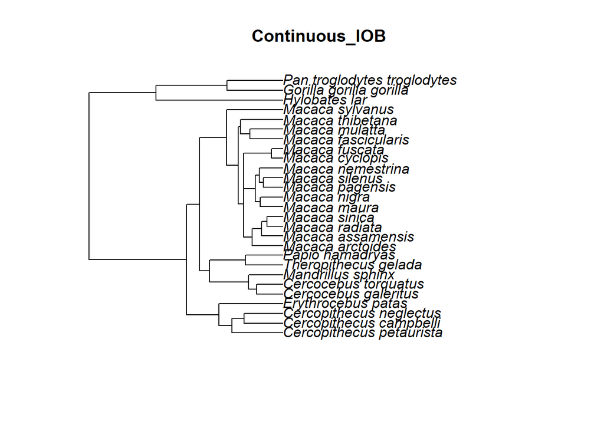

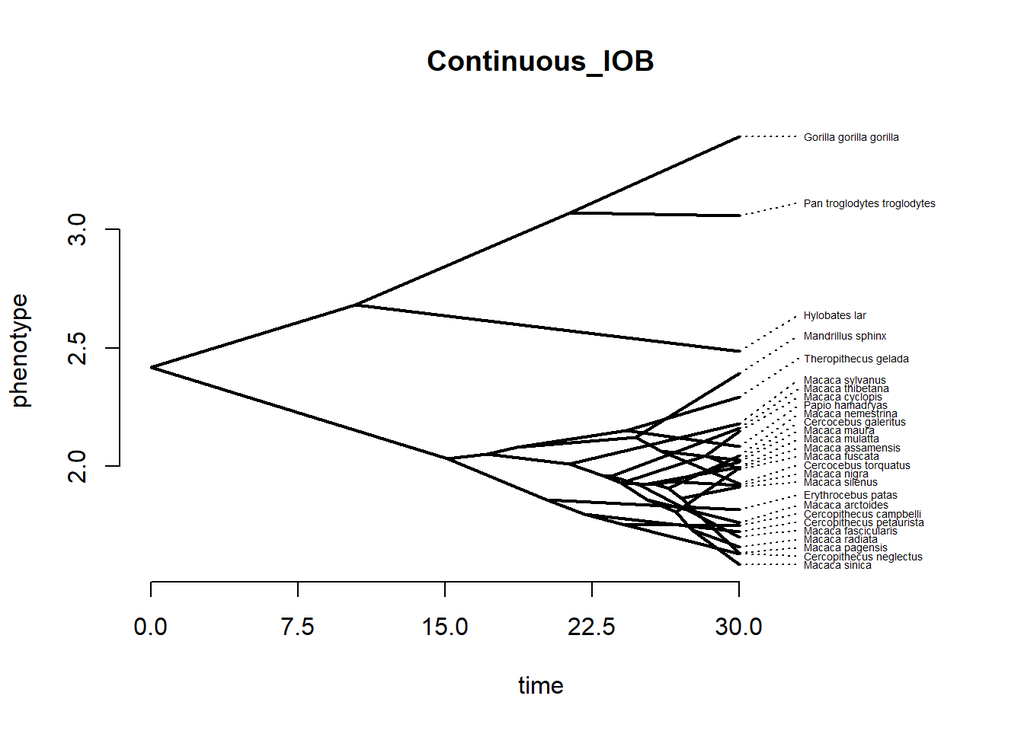

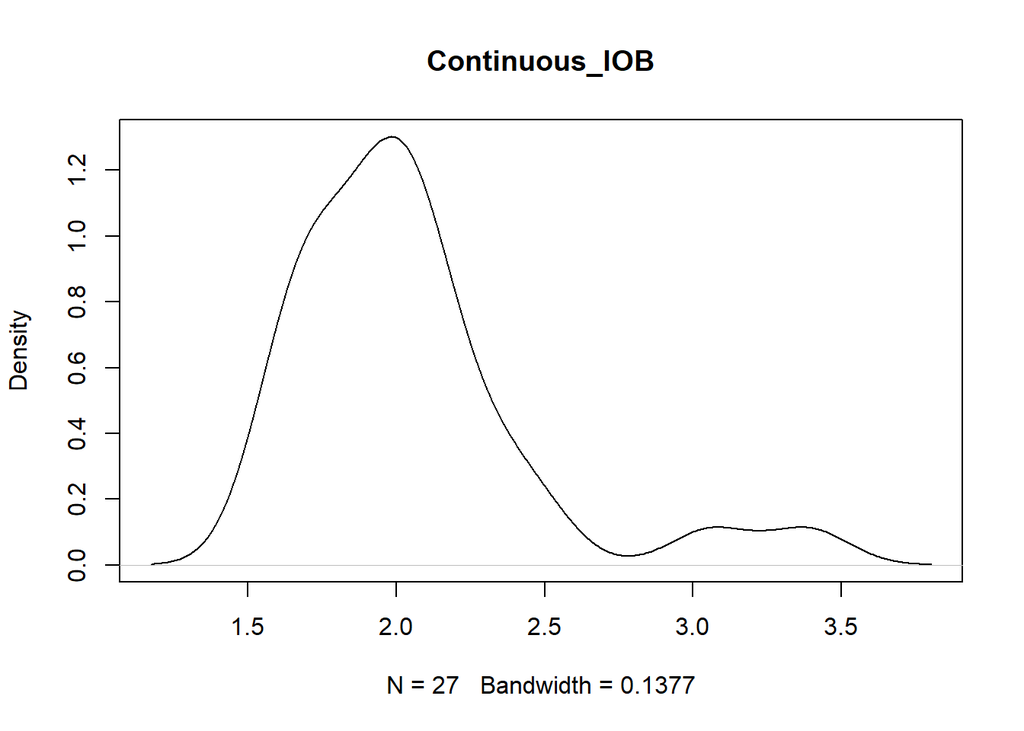

```r
VisualizeData(ult.phy.cont, cleaned.continuous[,1], "Continuous_IOB")
```

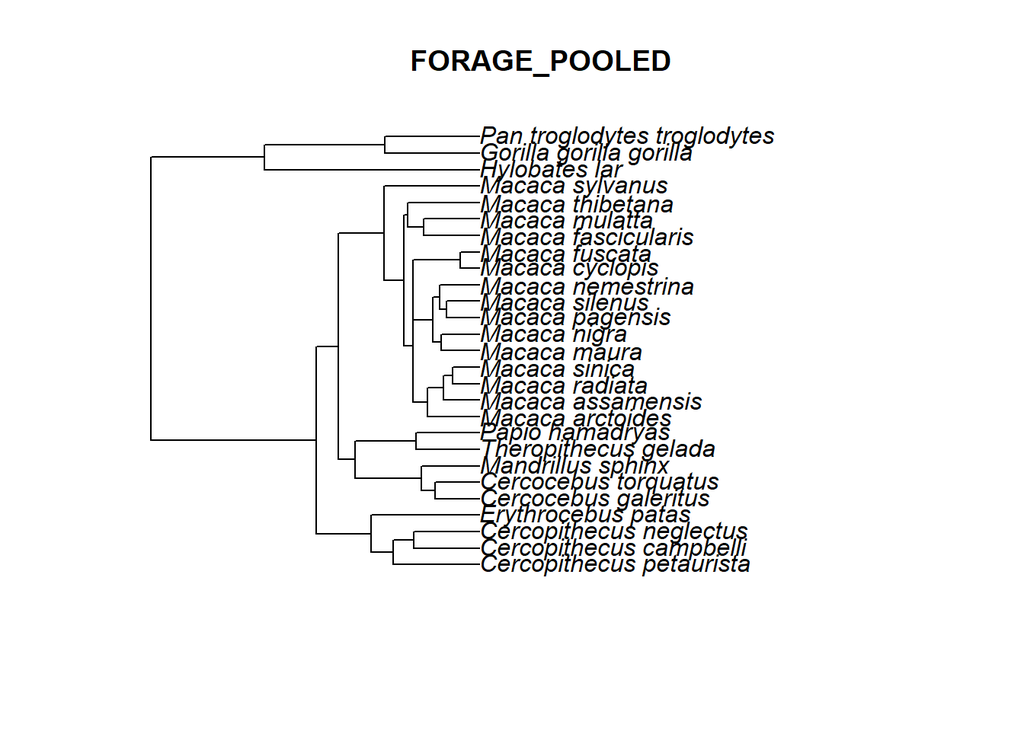

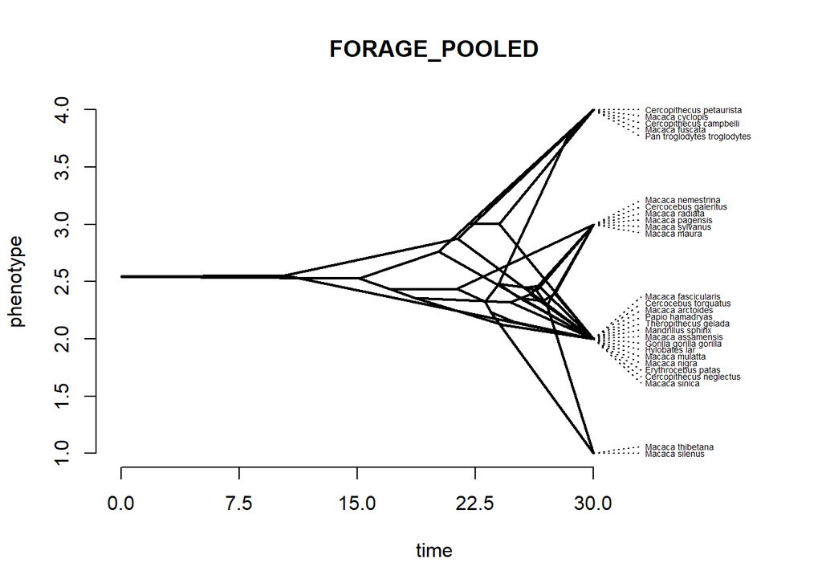

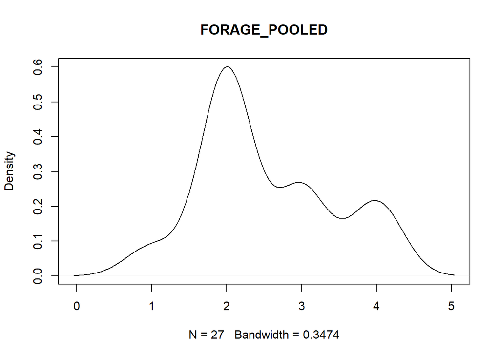

```r
VisualizeData(ult.phy.disc, cleaned.discrete[,1], "FORAGE_POOLED")
```

First, start basic. What is the rate of evolution of your trait on the tree?

```r
#First, start basic. What is the rate of evolution of your trait on the tree?

BM1 <- fitContinuous(ult.phy.cont, cleaned.continuous, model="BM")
print(paste("The rate of evolution is", "0.006838", "in units of", "log(interorbital breadth)^2/time"))
```

```
## [1] "The rate of evolution is 0.006838 in units of log(interorbital breadth)^2/time"
```

Important: What are the rates of evolution? In what units?

```r
ult.phy.cont.tinybrlen <- ult.phy.cont
ult.phy.cont.tinybrlen$edge.length[which(ult.phy.cont.tinybrlen$edge.length==0)] <- 1e-08

OU1 <- fitContinuous(ult.phy.cont.tinybrlen, cleaned.continuous, model="OU")
par(mfcol=(c(1,2)))
mod.alpha = OU1$opt$alpha
Plot.phy(ult.phy.cont.tinybrlen, "IOB_ALL")
```

[output not shown]

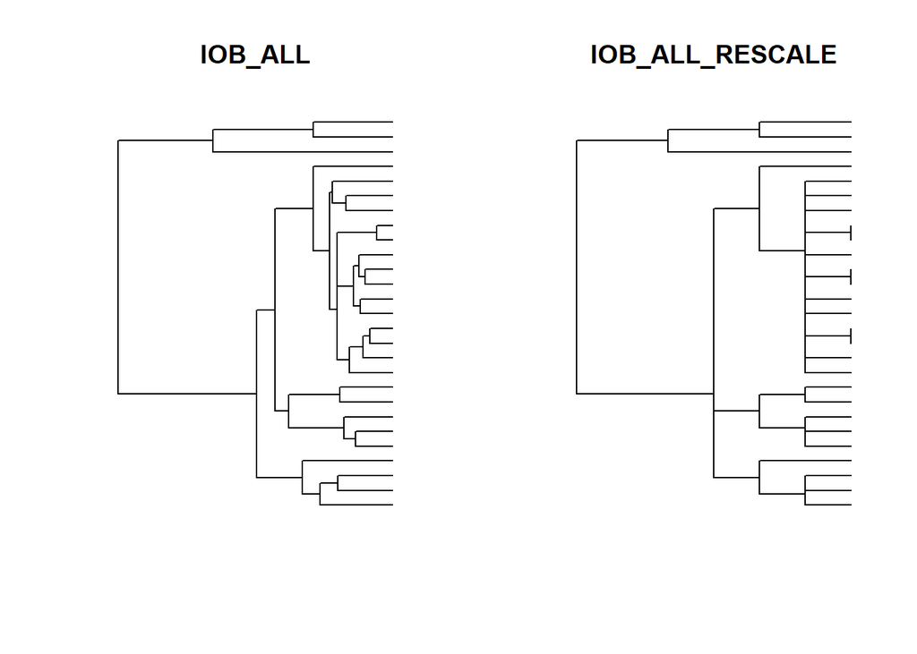

[output not shown]

```r
ou.tree <- geiger::rescale(ult.phy.cont.tinybrlen, model="OU", alpha = mod.alpha)
Plot.phy(ou.tree, "IOB_ALL_RESCALE")
```

How are the trees different?

Compare trees

```r
AIC.BM1 <- BM1$opt$aic
AIC.OU1 <- OU1$opt$aic
min.AIC = min(AIC.BM1, AIC.OU1)
delta.AIC.BM1 <- BM1$opt$aic - min.AIC
delta.AIC.OU1 <- OU1$opt$aic - min.AIC
print(c("Delta AIC BM1:", delta.AIC.BM1))
```

```
## [1] "Delta AIC BM1:" "0"
```

```r
print(c("Delta AIC OU1:", delta.AIC.OU1))
```

```
## [1] "Delta AIC OU1:"   "2.00000000235489"
```